```python
# This is just to enable improting the generated SDK from the examples folder in the pygen repository
import sys
from tests.constants import REPO_ROOT
sys.path.append(str(REPO_ROOT / "examples" ))
```

# Using Edges with Properties

Ofte edges in our data model is simply connecting two nodes. However, it is possible to have properties on edges as we have on nodes. This can be useful for filtering on these properties to select which nodes and edges we want.

In this example, we will use the model shonw below in the Cognite Data Fusion interface:

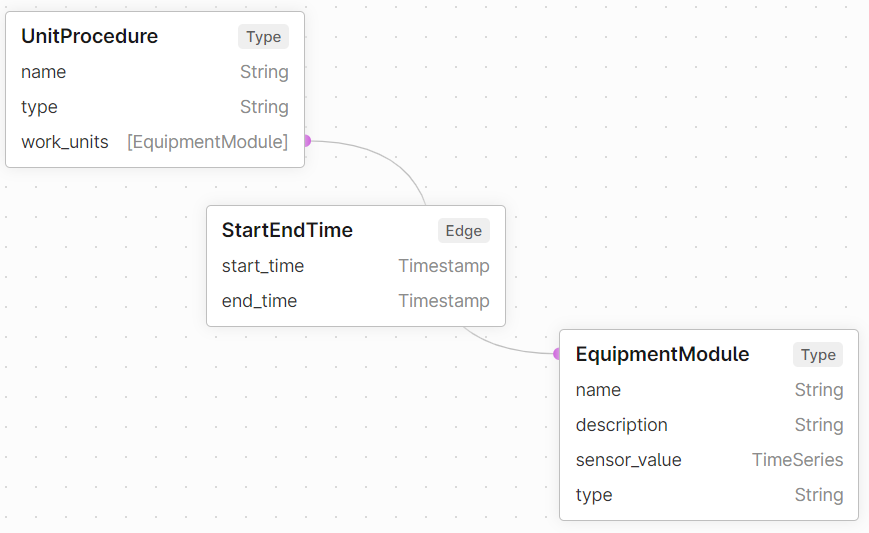

We note that we have one two `views`/`types` used for `nodes`, `UnitProcedure`and `EquipmentModule`, and one for edges `StartEndTime`. A `UnitProcedure` is connected through multiple `EquipmentModules` thorugh the `StartEndTime` edge.

First, we have to generate an SDK for the `EquipmentUnit` model. The call below shows a truncated version of the call used to generate the SDK.

```
pygen generate --client-name EquipmentUnitClient --to-level-package equipment_unit.client
```

Note that you can use any of the methods for generating the SDK as described in see the QuickStart guides.

Second, we have setup a `config.toml`in the current working directory with credentials to connect to Cognite Data Fusion

```python
from equipment_unit.client import EquipmentUnitClient
```

```python
workorders = EquipmentUnitClient.from_toml("config.toml")
```

## Listing and Filtering Edges

The `StartEndTime` edges are available on the `unit_procedure` class, and have a `list` method we can use to list and filter all edges of this type.

```python
workorders.unit_procedure.work_units.list(limit=5)
```

|  | external_id | end_time | start_time | equipment_module |
| --- | --- | --- | --- | --- |
| 0 | unit_procedure:Kelly Evans:equipment_module:Ja... | 2023-11-09 11:25:22+00:00 | 2023-11-01 12:19:16+00:00 | None |
| 1 | unit_procedure:Kelly Evans:equipment_module:Le... | 2023-10-28 19:31:25+00:00 | 2023-10-23 10:12:59+00:00 | None |
| 2 | unit_procedure:Kelly Evans:equipment_module:Gr... | 2023-11-13 18:01:26+00:00 | 2023-11-12 13:56:38+00:00 | None |
| 3 | unit_procedure:Kelly Evans:equipment_module:Ro... | 2023-11-11 23:23:43+00:00 | 2023-11-08 21:17:07+00:00 | None |
| 4 | unit_procedure:Kelly Evans:equipment_module:Aa... | 2023-11-09 01:52:04+00:00 | 2023-11-01 23:01:38+00:00 | None |

We can, for example, filter on the start of the edge, which are `UnitProcedures`.

First, we list a few unit procedures and selecet the `external_id` of one of them to filter on

```python
workorders.unit_procedure.list(limit=5, retrieve_edges=False)
```

|  | external_id | name | type_ | work_units |
| --- | --- | --- | --- | --- |
| 0 | unit_procedure:Kelly Evans | Kelly Evans | green | None |
| 1 | unit_procedure:Craig Carson | Craig Carson | yellow | None |
| 2 | unit_procedure:Felicia Smith | Felicia Smith | blue | None |
| 3 | unit_procedure:Scott Patel | Scott Patel | yellow | None |
| 4 | unit_procedure:Matthew Gonzalez | Matthew Gonzalez | red | None |

```python
from datetime import datetime, timezone
```

In addition, lets filter on the minimum start time

```python
workorders.unit_procedure.work_units.list(unit_procedure="unit_procedure:Scott Patel", min_start_time=datetime(2023, 11, 1, tzinfo=timezone.utc))
```

|  | external_id | end_time | start_time | equipment_module |
| --- | --- | --- | --- | --- |
| 0 | unit_procedure:Scott Patel:equipment_module:Mi... | 2023-11-07 18:58:39+00:00 | 2023-11-04 23:22:42+00:00 | None |

Or we can find all the edges that ends in a specific `EquipmentModule`.

```python
equipment = workorders.equipment_module.list(limit=5)
equipment
```

|  | external_id | description | name | sensor_value | type_ |
| --- | --- | --- | --- | --- | --- |
| 0 | equipment_module:Jamie Campbell | Study cover mouth party. Art get scene travel.... | Jamie Campbell | Common music like ahead meeting animal. Value ... | red |
| 1 | equipment_module:Lee Coleman | Item account east him heavy politics if. Six n... | Lee Coleman | Fill may perhaps. Leg law beautiful.\nRaise co... | red |
| 2 | equipment_module:Gregory Campbell | Suggest practice imagine amount occur wind lat... | Gregory Campbell | Beat turn put Mrs Mrs by PM individual.\nStudy... | red |
| 3 | equipment_module:Robert West | Listen director card nothing together red. Nat... | Robert West | Drive compare career American happy yet produc... | green |
| 4 | equipment_module:Aaron Vega | Computer leave again soldier source. Level com... | Aaron Vega | It painting the vote factor rate major. Struct... | yellow |

```python
workorders.unit_procedure.work_units.list(equipment_module="equipment_module:Gregory Campbell")
```

|  | external_id | end_time | start_time | equipment_module |
| --- | --- | --- | --- | --- |
| 0 | unit_procedure:Kelly Evans:equipment_module:Gr... | 2023-11-13 18:01:26+00:00 | 2023-11-12 13:56:38+00:00 | None |

## Filter Edges and Nodes

It can be cumbersome to first lookup the unit procedures and the equipment modules, and then, do another call to find the edges you want. In addition, you may not only want the `StartEndTime` edge but also the node, `EquipmentModule` at the end of the edges.

```python
unit_procedures = workorders.unit_procedure.work_units(type_="red").list(min_start_time=datetime(2023, 11, 1, tzinfo=timezone.utc), retrieve_equipment_module=True)
```

```python
unit_procedures
```

|  | external_id | name | type_ | work_units |
| --- | --- | --- | --- | --- |
| 0 | unit_procedure:Matthew Gonzalez | Matthew Gonzalez | red | [{'space': 'IntegrationTestsImmutable', 'exter... |

We note that this time we are getting a nested object back, meaning each of the unit procedures have edges to the equipment module with properties on them. We can illustrate this by looping through:

```python
from IPython.display import display, Markdown
```

```python
for unit_procedure in unit_procedures:
    display(Markdown(f"### Unit Procedure {unit_procedure.name}"))
    display(unit_procedure)
    display(Markdown("#### Work Units"))
    for work_unit in unit_procedure.work_units:
        display(Markdown("##### StartEndTime Edge"))
        display(work_unit)
        display(Markdown("##### Equipment Module"))
        display(work_unit.equipment_module)
        break
```

Unit Procedure Matthew Gonzalez

|  | value |
| --- | --- |
| external_id | unit_procedure:Matthew Gonzalez |
| name | Matthew Gonzalez |
| type_ | red |
| work_units | [{'space': 'IntegrationTestsImmutable', 'exter... |

Work Units

StartEndTime Edge

|  | value |
| --- | --- |
| external_id | unit_procedure:Matthew Gonzalez:equipment_modu... |
| end_time | 2023-11-11 14:33:45+00:00 |
| start_time | 2023-11-11 06:48:59+00:00 |
| equipment_module | {'space': 'IntegrationTestsImmutable', 'extern... |

Equipment Module

|  | value |
| --- | --- |
| external_id | equipment_module:Hannah Mcgee |
| description | Box likely camera short part different half. L... |
| name | Hannah Mcgee |
| sensor_value | Hospital wear trouble part about question. Def... |
| type_ | orange |

This type of queries that get nodes + edges back, which in our example, means the `UnitProcedure` with the `StartEndTime` edge and the `EquipmentModule` node, are more expensive than simply fetching the edges alone. Thus, it is recommended that you always filter to the few unit procedures you are interessted in, instead listing everything.

## Create Edges with Properties

Creating edges with properties are always done with the nodes these edges belong. This means, you cannot create edges alone, they always have to be connected to nodes.

The creation of edges are done as a step between the nodes when the edges has at least one property:

```python
from equipment_unit.client.data_classes import UnitProcedureApply, StartEndTimeApply, EquipmentModuleApply
```

```python
new_procedure = UnitProcedureApply(
        external_id="procedure:new_procedure",
        name="New procedure",
        type_="New type",
        work_units=[
            StartEndTimeApply(
                start_time="2021-01-01T00:00:00Z",
                end_time="2021-01-02T00:00:00Z",
                equipment_module=EquipmentModuleApply(
                    external_id="module:new_module",
                    name="New module",
                    type_="New type",
                    sensor_value="timeseries:123",
                    description="New description",
                ),
            ),
        ],
    )
```

We can now create the new procedure, `procedure:new_procedure` with one work_unit which is connected to the equipment module, `module:new_module`.

```python
workorders.unit_procedure.apply(new_procedure)
```